# Risk Factor Analysis

## Outcome Variable

**Outcome Variable:** stunted

## Predictor Variables

**Intervention Variable:** predexfd6

**Adjustment Set:**

- arm
- sex
- W_mage
- meducyrs
- feducyrs
- hhwealth_quart
- hfoodsec
- W_mhtcm
- vagbrth
- W_gagebrth
- W_birthwt
- W_birthlen
- W_nrooms
- W_nchldlt5
- month
- brthmon
- W_parity
- impfloor
- impsan
- safeh20
- delta_W_mage
- delta_meducyrs
- delta_feducyrs
- delta_hhwealth_quart
- delta_hfoodsec
- delta_W_mhtcm
- delta_vagbrth
- delta_W_gagebrth
- delta_W_birthwt
- delta_W_birthlen
- delta_W_nrooms
- delta_W_nchldlt5
- delta_month
- delta_brthmon
- delta_W_parity
- delta_impfloor
- delta_impsan
- delta_safeh20

## Stratifying Variables

The analysis was stratified on these variable(s):

- agecat
- studyid
- country

## Data Summary

| agecat | studyid | country | predexfd6 | stunted | n_cell | n |
| --- | --- | --- | --- | --- | --- | --- |
| Birth | ki0047075b-MAL-ED | BANGLADESH | 1 | 0 | 101 | 231 |
| Birth | ki0047075b-MAL-ED | BANGLADESH | 1 | 1 | 18 | 231 |
| Birth | ki0047075b-MAL-ED | BANGLADESH | 0 | 0 | 91 | 231 |
| Birth | ki0047075b-MAL-ED | BANGLADESH | 0 | 1 | 21 | 231 |
| Birth | ki0047075b-MAL-ED | BRAZIL | 1 | 0 | 24 | 175 |
| Birth | ki0047075b-MAL-ED | BRAZIL | 1 | 1 | 3 | 175 |
| Birth | ki0047075b-MAL-ED | BRAZIL | 0 | 0 | 134 | 175 |
| Birth | ki0047075b-MAL-ED | BRAZIL | 0 | 1 | 14 | 175 |
| Birth | ki0047075b-MAL-ED | INDIA | 1 | 0 | 10 | 190 |
| Birth | ki0047075b-MAL-ED | INDIA | 1 | 1 | 5 | 190 |
| Birth | ki0047075b-MAL-ED | INDIA | 0 | 0 | 149 | 190 |
| Birth | ki0047075b-MAL-ED | INDIA | 0 | 1 | 26 | 190 |
| Birth | ki0047075b-MAL-ED | NEPAL | 1 | 0 | 21 | 170 |
| Birth | ki0047075b-MAL-ED | NEPAL | 1 | 1 | 2 | 170 |
| Birth | ki0047075b-MAL-ED | NEPAL | 0 | 0 | 131 | 170 |
| Birth | ki0047075b-MAL-ED | NEPAL | 0 | 1 | 16 | 170 |
| Birth | ki0047075b-MAL-ED | PERU | 1 | 0 | 95 | 256 |
| Birth | ki0047075b-MAL-ED | PERU | 1 | 1 | 11 | 256 |
| Birth | ki0047075b-MAL-ED | PERU | 0 | 0 | 132 | 256 |
| Birth | ki0047075b-MAL-ED | PERU | 0 | 1 | 18 | 256 |
| Birth | ki0047075b-MAL-ED | SOUTH AFRICA | 1 | 0 | 1 | 211 |
| Birth | ki0047075b-MAL-ED | SOUTH AFRICA | 1 | 1 | 2 | 211 |
| Birth | ki0047075b-MAL-ED | SOUTH AFRICA | 0 | 0 | 188 | 211 |
| Birth | ki0047075b-MAL-ED | SOUTH AFRICA | 0 | 1 | 20 | 211 |
| Birth | ki0047075b-MAL-ED | TANZANIA, UNITED REPUBLIC OF | 1 | 0 | 1 | 119 |
| Birth | ki0047075b-MAL-ED | TANZANIA, UNITED REPUBLIC OF | 1 | 1 | 0 | 119 |
| Birth | ki0047075b-MAL-ED | TANZANIA, UNITED REPUBLIC OF | 0 | 0 | 102 | 119 |
| Birth | ki0047075b-MAL-ED | TANZANIA, UNITED REPUBLIC OF | 0 | 1 | 16 | 119 |
| Birth | ki1000108-CMC-V-BCS-2002 | INDIA | 1 | 0 | 7 | 7 |
| Birth | ki1000108-CMC-V-BCS-2002 | INDIA | 1 | 1 | 0 | 7 |

[output cut: 158 more lines]

The following strata were considered:

- agecat: 24 months, studyid: ki0047075b-MAL-ED, country: BANGLADESH
- agecat: 24 months, studyid: ki0047075b-MAL-ED, country: BRAZIL
- agecat: 24 months, studyid: ki0047075b-MAL-ED, country: INDIA
- agecat: 24 months, studyid: ki0047075b-MAL-ED, country: NEPAL
- agecat: 24 months, studyid: ki0047075b-MAL-ED, country: PERU
- agecat: 24 months, studyid: ki0047075b-MAL-ED, country: SOUTH AFRICA
- agecat: 24 months, studyid: ki0047075b-MAL-ED, country: TANZANIA, UNITED REPUBLIC OF
- agecat: 24 months, studyid: ki1000108-CMC-V-BCS-2002, country: INDIA
- agecat: 24 months, studyid: ki1000108-IRC, country: INDIA
- agecat: 24 months, studyid: ki1017093b-PROVIDE, country: BANGLADESH
- agecat: 24 months, studyid: ki1101329-Keneba, country: GAMBIA
- agecat: 24 months, studyid: ki1113344-GMS-Nepal, country: NEPAL
- agecat: 24 months, studyid: ki1148112-LCNI-5, country: MALAWI
- agecat: 24 months, studyid: kiGH5241-JiVitA-3, country: BANGLADESH
- agecat: 24 months, studyid: kiGH5241-JiVitA-4, country: BANGLADESH
- agecat: 6 months, studyid: ki0047075b-MAL-ED, country: BANGLADESH
- agecat: 6 months, studyid: ki0047075b-MAL-ED, country: BRAZIL
- agecat: 6 months, studyid: ki0047075b-MAL-ED, country: INDIA
- agecat: 6 months, studyid: ki0047075b-MAL-ED, country: NEPAL
- agecat: 6 months, studyid: ki0047075b-MAL-ED, country: PERU
- agecat: 6 months, studyid: ki0047075b-MAL-ED, country: SOUTH AFRICA
- agecat: 6 months, studyid: ki0047075b-MAL-ED, country: TANZANIA, UNITED REPUBLIC OF
- agecat: 6 months, studyid: ki1000108-CMC-V-BCS-2002, country: INDIA
- agecat: 6 months, studyid: ki1000108-IRC, country: INDIA
- agecat: 6 months, studyid: ki1000109-EE, country: PAKISTAN
- agecat: 6 months, studyid: ki1000304b-SAS-CompFeed, country: INDIA
- agecat: 6 months, studyid: ki1000304b-SAS-FoodSuppl, country: INDIA
- agecat: 6 months, studyid: ki1017093b-PROVIDE, country: BANGLADESH
- agecat: 6 months, studyid: ki1101329-Keneba, country: GAMBIA
- agecat: 6 months, studyid: ki1113344-GMS-Nepal, country: NEPAL
- agecat: 6 months, studyid: ki1148112-LCNI-5, country: MALAWI
- agecat: 6 months, studyid: kiGH5241-JiVitA-3, country: BANGLADESH
- agecat: 6 months, studyid: kiGH5241-JiVitA-4, country: BANGLADESH
- agecat: Birth, studyid: ki0047075b-MAL-ED, country: BANGLADESH
- agecat: Birth, studyid: ki0047075b-MAL-ED, country: BRAZIL
- agecat: Birth, studyid: ki0047075b-MAL-ED, country: INDIA
- agecat: Birth, studyid: ki0047075b-MAL-ED, country: NEPAL
- agecat: Birth, studyid: ki0047075b-MAL-ED, country: PERU
- agecat: Birth, studyid: ki0047075b-MAL-ED, country: SOUTH AFRICA
- agecat: Birth, studyid: ki0047075b-MAL-ED, country: TANZANIA, UNITED REPUBLIC OF
- agecat: Birth, studyid: ki1000108-CMC-V-BCS-2002, country: INDIA
- agecat: Birth, studyid: ki1000108-IRC, country: INDIA
- agecat: Birth, studyid: ki1000109-EE, country: PAKISTAN
- agecat: Birth, studyid: ki1000304b-SAS-CompFeed, country: INDIA
- agecat: Birth, studyid: ki1101329-Keneba, country: GAMBIA
- agecat: Birth, studyid: kiGH5241-JiVitA-3, country: BANGLADESH
- agecat: Birth, studyid: kiGH5241-JiVitA-4, country: BANGLADESH

### Dropped Strata

Some strata were dropped due to rare outcomes:

- agecat: Birth, studyid: ki0047075b-MAL-ED, country: BRAZIL
- agecat: Birth, studyid: ki0047075b-MAL-ED, country: NEPAL
- agecat: Birth, studyid: ki0047075b-MAL-ED, country: SOUTH AFRICA
- agecat: Birth, studyid: ki0047075b-MAL-ED, country: TANZANIA, UNITED REPUBLIC OF
- agecat: Birth, studyid: ki1000108-CMC-V-BCS-2002, country: INDIA
- agecat: Birth, studyid: ki1000108-IRC, country: INDIA
- agecat: Birth, studyid: ki1000109-EE, country: PAKISTAN
- agecat: Birth, studyid: ki1000304b-SAS-CompFeed, country: INDIA
- agecat: 6 months, studyid: ki0047075b-MAL-ED, country: BRAZIL
- agecat: 6 months, studyid: ki0047075b-MAL-ED, country: NEPAL
- agecat: 6 months, studyid: ki0047075b-MAL-ED, country: SOUTH AFRICA
- agecat: 6 months, studyid: ki0047075b-MAL-ED, country: TANZANIA, UNITED REPUBLIC OF
- agecat: 6 months, studyid: ki1000108-CMC-V-BCS-2002, country: INDIA
- agecat: 6 months, studyid: ki1000108-IRC, country: INDIA
- agecat: 6 months, studyid: ki1000304b-SAS-FoodSuppl, country: INDIA
- agecat: 24 months, studyid: ki0047075b-MAL-ED, country: BRAZIL
- agecat: 24 months, studyid: ki0047075b-MAL-ED, country: SOUTH AFRICA
- agecat: 24 months, studyid: ki0047075b-MAL-ED, country: TANZANIA, UNITED REPUBLIC OF
- agecat: 24 months, studyid: ki1000108-CMC-V-BCS-2002, country: INDIA
- agecat: 24 months, studyid: ki1000108-IRC, country: INDIA

## Methods Detail

We’re interested in the causal parameters $E[Y_a]$ for all values of $a \in \mathcal{A}$. These parameters represent the mean outcome if, possibly contrary to fact, we intervened to set all units to have $A=a$. Under the randomization and positivity assumptions, these are identified by the statistical parameters $\psi_a=E_W[E_{Y|A,W}(Y|A=a,W)]$. In addition, we’re interested in the mean of $Y$, $E[Y]$ under no intervention (the observed mean). We will estimate these parameters by using SuperLearner to fit the relevant likelihood factors – $E_{Y|A,W}(Y|A=a,W)$ and $p(A=a|W)$, and then updating our likelihood fit using a joint TMLE.

For unadjusted analyses ($W=\{\}$), initial likelihoods were estimated using Lrnr_glm to estimate the simple $E(Y|A)$ and Lrnr_mean to estimate $p(A)$. For adjusted analyses, a small library containing Lrnr_glmnet, Lrnr_xgboost, and Lrnr_mean was used.

Having estimated these parameters, we will then use the delta method to estimate relative risks and attributable risks relative to a prespecified baseline level of $A$.

# Results Detail

## Results Plots

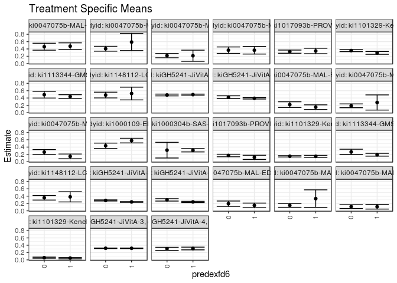

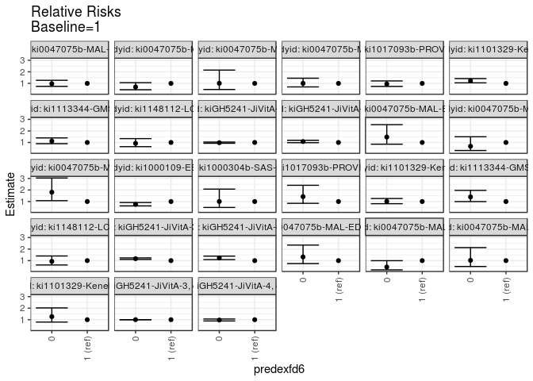

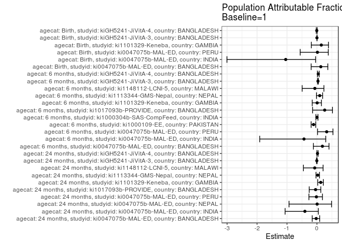

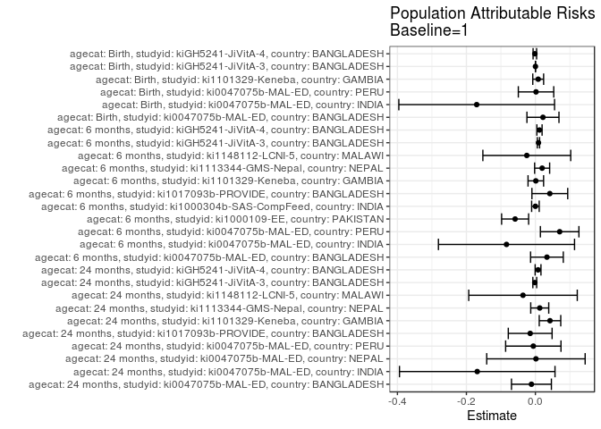

## Results Table

### Parameter: TSM

| agecat | studyid | country | intervention_level | baseline_level | estimate | ci_lower | ci_upper |
| --- | --- | --- | --- | --- | --- | --- | --- |
| Birth | ki0047075b-MAL-ED | BANGLADESH | 1 | NA | 0.1469206 | 0.0832200 | 0.2106212 |
| Birth | ki0047075b-MAL-ED | BANGLADESH | 0 | NA | 0.1939707 | 0.1207179 | 0.2672235 |
| Birth | ki0047075b-MAL-ED | INDIA | 1 | NA | 0.3333333 | 0.0941438 | 0.5725228 |
| Birth | ki0047075b-MAL-ED | INDIA | 0 | NA | 0.1485714 | 0.0957370 | 0.2014058 |
| Birth | ki0047075b-MAL-ED | PERU | 1 | NA | 0.1114151 | 0.0472394 | 0.1755909 |
| Birth | ki0047075b-MAL-ED | PERU | 0 | NA | 0.1140247 | 0.0628368 | 0.1652127 |
| Birth | ki1101329-Keneba | GAMBIA | 1 | NA | 0.0475388 | 0.0284176 | 0.0666600 |
| Birth | ki1101329-Keneba | GAMBIA | 0 | NA | 0.0602226 | 0.0451428 | 0.0753025 |
| Birth | kiGH5241-JiVitA-3 | BANGLADESH | 1 | NA | 0.3164963 | 0.3088853 | 0.3241074 |
| Birth | kiGH5241-JiVitA-3 | BANGLADESH | 0 | NA | 0.3170384 | 0.3094312 | 0.3246456 |
| Birth | kiGH5241-JiVitA-4 | BANGLADESH | 1 | NA | 0.3105876 | 0.2732769 | 0.3478983 |
| Birth | kiGH5241-JiVitA-4 | BANGLADESH | 0 | NA | 0.3016965 | 0.2598098 | 0.3435831 |
| 6 months | ki0047075b-MAL-ED | BANGLADESH | 1 | NA | 0.1495056 | 0.0856237 | 0.2133874 |
| 6 months | ki0047075b-MAL-ED | BANGLADESH | 0 | NA | 0.2197934 | 0.1425126 | 0.2970741 |
| 6 months | ki0047075b-MAL-ED | INDIA | 1 | NA | 0.2777778 | 0.0704135 | 0.4851421 |
| 6 months | ki0047075b-MAL-ED | INDIA | 0 | NA | 0.1869159 | 0.1345715 | 0.2392603 |
| 6 months | ki0047075b-MAL-ED | PERU | 1 | NA | 0.1452576 | 0.0801614 | 0.2103538 |
| 6 months | ki0047075b-MAL-ED | PERU | 0 | NA | 0.2624530 | 0.1924649 | 0.3324411 |
| 6 months | ki1000109-EE | PAKISTAN | 1 | NA | 0.5776069 | 0.5139756 | 0.6412381 |
| 6 months | ki1000109-EE | PAKISTAN | 0 | NA | 0.4358239 | 0.3622543 | 0.5093935 |
| 6 months | ki1000304b-SAS-CompFeed | INDIA | 1 | NA | 0.3139842 | 0.2679102 | 0.3600581 |
| 6 months | ki1000304b-SAS-CompFeed | INDIA | 0 | NA | 0.3157895 | 0.1014523 | 0.5301266 |
| 6 months | ki1017093b-PROVIDE | BANGLADESH | 1 | NA | 0.1194304 | 0.0615821 | 0.1772788 |
| 6 months | ki1017093b-PROVIDE | BANGLADESH | 0 | NA | 0.1702094 | 0.1353836 | 0.2050351 |
| 6 months | ki1101329-Keneba | GAMBIA | 1 | NA | 0.1465835 | 0.1190748 | 0.1740922 |
| 6 months | ki1101329-Keneba | GAMBIA | 0 | NA | 0.1484501 | 0.1295836 | 0.1673166 |
| 6 months | ki1113344-GMS-Nepal | NEPAL | 1 | NA | 0.1910609 | 0.1526046 | 0.2295173 |
| 6 months | ki1113344-GMS-Nepal | NEPAL | 0 | NA | 0.2674546 | 0.1936807 | 0.3412286 |
| 6 months | ki1148112-LCNI-5 | MALAWI | 1 | NA | 0.3815317 | 0.2420183 | 0.5210452 |
| 6 months | ki1148112-LCNI-5 | MALAWI | 0 | NA | 0.3557822 | 0.2930578 | 0.4185065 |
| 6 months | kiGH5241-JiVitA-3 | BANGLADESH | 1 | NA | 0.2419271 | 0.2331759 | 0.2506783 |
| 6 months | kiGH5241-JiVitA-3 | BANGLADESH | 0 | NA | 0.2827963 | 0.2680192 | 0.2975733 |
| 6 months | kiGH5241-JiVitA-4 | BANGLADESH | 1 | NA | 0.2426915 | 0.2266238 | 0.2587592 |
| 6 months | kiGH5241-JiVitA-4 | BANGLADESH | 0 | NA | 0.2986302 | 0.2656062 | 0.3316542 |
| 24 months | ki0047075b-MAL-ED | BANGLADESH | 1 | NA | 0.4755835 | 0.3854552 | 0.5657118 |
| 24 months | ki0047075b-MAL-ED | BANGLADESH | 0 | NA | 0.4608763 | 0.3659592 | 0.5557935 |
| 24 months | ki0047075b-MAL-ED | INDIA | 1 | NA | 0.5882353 | 0.3537610 | 0.8227096 |
| 24 months | ki0047075b-MAL-ED | INDIA | 0 | NA | 0.4057971 | 0.3387537 | 0.4728406 |
| 24 months | ki0047075b-MAL-ED | NEPAL | 1 | NA | 0.2142857 | 0.0619658 | 0.3666056 |
| 24 months | ki0047075b-MAL-ED | NEPAL | 0 | NA | 0.2160804 | 0.1587713 | 0.2733895 |
| 24 months | ki0047075b-MAL-ED | PERU | 1 | NA | 0.3646397 | 0.2604148 | 0.4688645 |
| 24 months | ki0047075b-MAL-ED | PERU | 0 | NA | 0.3658133 | 0.2776038 | 0.4540229 |
| 24 months | ki1017093b-PROVIDE | BANGLADESH | 1 | NA | 0.3443778 | 0.2692361 | 0.4195195 |
| 24 months | ki1017093b-PROVIDE | BANGLADESH | 0 | NA | 0.3258183 | 0.2825676 | 0.3690689 |
| 24 months | ki1101329-Keneba | GAMBIA | 1 | NA | 0.2920991 | 0.2538006 | 0.3303975 |
| 24 months | ki1101329-Keneba | GAMBIA | 0 | NA | 0.3555390 | 0.3262891 | 0.3847889 |
| 24 months | ki1113344-GMS-Nepal | NEPAL | 1 | NA | 0.4394905 | 0.3881752 | 0.4908059 |
| 24 months | ki1113344-GMS-Nepal | NEPAL | 0 | NA | 0.4908454 | 0.3991161 | 0.5825747 |
| 24 months | ki1148112-LCNI-5 | MALAWI | 1 | NA | 0.5226848 | 0.3484733 | 0.6968963 |
| 24 months | ki1148112-LCNI-5 | MALAWI | 0 | NA | 0.4810611 | 0.4024102 | 0.5597121 |
| 24 months | kiGH5241-JiVitA-3 | BANGLADESH | 1 | NA | 0.4925732 | 0.4782912 | 0.5068553 |
| 24 months | kiGH5241-JiVitA-3 | BANGLADESH | 0 | NA | 0.4825016 | 0.4582433 | 0.5067599 |
| 24 months | kiGH5241-JiVitA-4 | BANGLADESH | 1 | NA | 0.3914285 | 0.3718223 | 0.4110347 |
| 24 months | kiGH5241-JiVitA-4 | BANGLADESH | 0 | NA | 0.4225608 | 0.3842821 | 0.4608395 |

### Parameter: E(Y)

| agecat | studyid | country | intervention_level | baseline_level | estimate | ci_lower | ci_upper |
| --- | --- | --- | --- | --- | --- | --- | --- |
| Birth | ki0047075b-MAL-ED | BANGLADESH | NA | NA | 0.1688312 | 0.1204189 | 0.2172434 |
| Birth | ki0047075b-MAL-ED | INDIA | NA | NA | 0.1631579 | 0.1104782 | 0.2158376 |
| Birth | ki0047075b-MAL-ED | PERU | NA | NA | 0.1132813 | 0.0743812 | 0.1521813 |
| Birth | ki1101329-Keneba | GAMBIA | NA | NA | 0.0556745 | 0.0436637 | 0.0676854 |
| Birth | kiGH5241-JiVitA-3 | BANGLADESH | NA | NA | 0.3166335 | 0.3090239 | 0.3242430 |
| Birth | kiGH5241-JiVitA-4 | BANGLADESH | NA | NA | 0.3089961 | 0.2722361 | 0.3457561 |
| 6 months | ki0047075b-MAL-ED | BANGLADESH | NA | NA | 0.1829787 | 0.1334386 | 0.2325189 |
| 6 months | ki0047075b-MAL-ED | INDIA | NA | NA | 0.1939655 | 0.1429760 | 0.2449551 |
| 6 months | ki0047075b-MAL-ED | PERU | NA | NA | 0.2156134 | 0.1663773 | 0.2648495 |
| 6 months | ki1000109-EE | PAKISTAN | NA | NA | 0.5188172 | 0.4679751 | 0.5696593 |
| 6 months | ki1000304b-SAS-CompFeed | INDIA | NA | NA | 0.3140704 | 0.2712850 | 0.3568557 |
| 6 months | ki1017093b-PROVIDE | BANGLADESH | NA | NA | 0.1612350 | 0.1313580 | 0.1911120 |
| 6 months | ki1101329-Keneba | GAMBIA | NA | NA | 0.1477987 | 0.1318701 | 0.1637274 |
| 6 months | ki1113344-GMS-Nepal | NEPAL | NA | NA | 0.2106227 | 0.1763897 | 0.2448557 |
| 6 months | ki1148112-LCNI-5 | MALAWI | NA | NA | 0.3566176 | 0.2995882 | 0.4136471 |
| 6 months | kiGH5241-JiVitA-3 | BANGLADESH | NA | NA | 0.2508093 | 0.2426385 | 0.2589801 |
| 6 months | kiGH5241-JiVitA-4 | BANGLADESH | NA | NA | 0.2545198 | 0.2394884 | 0.2695513 |
| 24 months | ki0047075b-MAL-ED | BANGLADESH | NA | NA | 0.4641148 | 0.3963405 | 0.5318891 |
| 24 months | ki0047075b-MAL-ED | INDIA | NA | NA | 0.4196429 | 0.3548715 | 0.4844143 |
| 24 months | ki0047075b-MAL-ED | NEPAL | NA | NA | 0.2158590 | 0.1622206 | 0.2694975 |
| 24 months | ki0047075b-MAL-ED | PERU | NA | NA | 0.3585859 | 0.2916158 | 0.4255559 |
| 24 months | ki1017093b-PROVIDE | BANGLADESH | NA | NA | 0.3292894 | 0.2909105 | 0.3676684 |
| 24 months | ki1101329-Keneba | GAMBIA | NA | NA | 0.3344349 | 0.3106543 | 0.3582155 |
| 24 months | ki1113344-GMS-Nepal | NEPAL | NA | NA | 0.4520833 | 0.4075129 | 0.4966538 |
| 24 months | ki1148112-LCNI-5 | MALAWI | NA | NA | 0.4867725 | 0.4153250 | 0.5582200 |
| 24 months | kiGH5241-JiVitA-3 | BANGLADESH | NA | NA | 0.4907516 | 0.4775997 | 0.5039035 |
| 24 months | kiGH5241-JiVitA-4 | BANGLADESH | NA | NA | 0.3991375 | 0.3806098 | 0.4176653 |

### Parameter: RR

| agecat | studyid | country | intervention_level | baseline_level | estimate | ci_lower | ci_upper |
| --- | --- | --- | --- | --- | --- | --- | --- |
| Birth | ki0047075b-MAL-ED | BANGLADESH | 1 | 1 | 1.0000000 | 1.0000000 | 1.0000000 |
| Birth | ki0047075b-MAL-ED | BANGLADESH | 0 | 1 | 1.3202422 | 0.7431590 | 2.3454462 |
| Birth | ki0047075b-MAL-ED | INDIA | 1 | 1 | 1.0000000 | 1.0000000 | 1.0000000 |
| Birth | ki0047075b-MAL-ED | INDIA | 0 | 1 | 0.4457143 | 0.2001014 | 0.9928030 |
| Birth | ki0047075b-MAL-ED | PERU | 1 | 1 | 1.0000000 | 1.0000000 | 1.0000000 |
| Birth | ki0047075b-MAL-ED | PERU | 0 | 1 | 1.0234221 | 0.4919821 | 2.1289247 |
| Birth | ki1101329-Keneba | GAMBIA | 1 | 1 | 1.0000000 | 1.0000000 | 1.0000000 |
| Birth | ki1101329-Keneba | GAMBIA | 0 | 1 | 1.2668102 | 0.7940588 | 2.0210192 |
| Birth | kiGH5241-JiVitA-3 | BANGLADESH | 1 | 1 | 1.0000000 | 1.0000000 | 1.0000000 |
| Birth | kiGH5241-JiVitA-3 | BANGLADESH | 0 | 1 | 1.0017126 | 1.0008284 | 1.0025976 |
| Birth | kiGH5241-JiVitA-4 | BANGLADESH | 1 | 1 | 1.0000000 | 1.0000000 | 1.0000000 |
| Birth | kiGH5241-JiVitA-4 | BANGLADESH | 0 | 1 | 0.9713732 | 0.8906313 | 1.0594349 |
| 6 months | ki0047075b-MAL-ED | BANGLADESH | 1 | 1 | 1.0000000 | 1.0000000 | 1.0000000 |
| 6 months | ki0047075b-MAL-ED | BANGLADESH | 0 | 1 | 1.4701350 | 0.8499310 | 2.5429089 |
| 6 months | ki0047075b-MAL-ED | INDIA | 1 | 1 | 1.0000000 | 1.0000000 | 1.0000000 |
| 6 months | ki0047075b-MAL-ED | INDIA | 0 | 1 | 0.6728972 | 0.3031666 | 1.4935372 |
| 6 months | ki0047075b-MAL-ED | PERU | 1 | 1 | 1.0000000 | 1.0000000 | 1.0000000 |
| 6 months | ki0047075b-MAL-ED | PERU | 0 | 1 | 1.8068108 | 1.0733929 | 3.0413518 |
| 6 months | ki1000109-EE | PAKISTAN | 1 | 1 | 1.0000000 | 1.0000000 | 1.0000000 |
| 6 months | ki1000109-EE | PAKISTAN | 0 | 1 | 0.7545338 | 0.6227521 | 0.9142021 |
| 6 months | ki1000304b-SAS-CompFeed | INDIA | 1 | 1 | 1.0000000 | 1.0000000 | 1.0000000 |
| 6 months | ki1000304b-SAS-CompFeed | INDIA | 0 | 1 | 1.0057497 | 0.4866253 | 2.0786680 |
| 6 months | ki1017093b-PROVIDE | BANGLADESH | 1 | 1 | 1.0000000 | 1.0000000 | 1.0000000 |
| 6 months | ki1017093b-PROVIDE | BANGLADESH | 0 | 1 | 1.4251758 | 0.8437739 | 2.4071925 |
| 6 months | ki1101329-Keneba | GAMBIA | 1 | 1 | 1.0000000 | 1.0000000 | 1.0000000 |
| 6 months | ki1101329-Keneba | GAMBIA | 0 | 1 | 1.0127344 | 0.8122323 | 1.2627310 |
| 6 months | ki1113344-GMS-Nepal | NEPAL | 1 | 1 | 1.0000000 | 1.0000000 | 1.0000000 |
| 6 months | ki1113344-GMS-Nepal | NEPAL | 0 | 1 | 1.3998394 | 0.9948619 | 1.9696706 |
| 6 months | ki1148112-LCNI-5 | MALAWI | 1 | 1 | 1.0000000 | 1.0000000 | 1.0000000 |
| 6 months | ki1148112-LCNI-5 | MALAWI | 0 | 1 | 0.9325101 | 0.6207935 | 1.4007478 |
| 6 months | kiGH5241-JiVitA-3 | BANGLADESH | 1 | 1 | 1.0000000 | 1.0000000 | 1.0000000 |
| 6 months | kiGH5241-JiVitA-3 | BANGLADESH | 0 | 1 | 1.1689319 | 1.1045689 | 1.2370453 |
| 6 months | kiGH5241-JiVitA-4 | BANGLADESH | 1 | 1 | 1.0000000 | 1.0000000 | 1.0000000 |
| 6 months | kiGH5241-JiVitA-4 | BANGLADESH | 0 | 1 | 1.2304933 | 1.0889268 | 1.3904642 |
| 24 months | ki0047075b-MAL-ED | BANGLADESH | 1 | 1 | 1.0000000 | 1.0000000 | 1.0000000 |
| 24 months | ki0047075b-MAL-ED | BANGLADESH | 0 | 1 | 0.9690755 | 0.7415603 | 1.2663938 |
| 24 months | ki0047075b-MAL-ED | INDIA | 1 | 1 | 1.0000000 | 1.0000000 | 1.0000000 |
| 24 months | ki0047075b-MAL-ED | INDIA | 0 | 1 | 0.6898551 | 0.4480893 | 1.0620652 |
| 24 months | ki0047075b-MAL-ED | NEPAL | 1 | 1 | 1.0000000 | 1.0000000 | 1.0000000 |
| 24 months | ki0047075b-MAL-ED | NEPAL | 0 | 1 | 1.0083752 | 0.4721996 | 2.1533703 |
| 24 months | ki0047075b-MAL-ED | PERU | 1 | 1 | 1.0000000 | 1.0000000 | 1.0000000 |
| 24 months | ki0047075b-MAL-ED | PERU | 0 | 1 | 1.0032187 | 0.6945806 | 1.4490008 |
| 24 months | ki1017093b-PROVIDE | BANGLADESH | 1 | 1 | 1.0000000 | 1.0000000 | 1.0000000 |
| 24 months | ki1017093b-PROVIDE | BANGLADESH | 0 | 1 | 0.9461071 | 0.7378696 | 1.2131121 |
| 24 months | ki1101329-Keneba | GAMBIA | 1 | 1 | 1.0000000 | 1.0000000 | 1.0000000 |
| 24 months | ki1101329-Keneba | GAMBIA | 0 | 1 | 1.2171864 | 1.0462850 | 1.4160030 |
| 24 months | ki1113344-GMS-Nepal | NEPAL | 1 | 1 | 1.0000000 | 1.0000000 | 1.0000000 |
| 24 months | ki1113344-GMS-Nepal | NEPAL | 0 | 1 | 1.1168509 | 0.8959334 | 1.3922419 |
| 24 months | ki1148112-LCNI-5 | MALAWI | 1 | 1 | 1.0000000 | 1.0000000 | 1.0000000 |
| 24 months | ki1148112-LCNI-5 | MALAWI | 0 | 1 | 0.9203656 | 0.6352383 | 1.3334725 |
| 24 months | kiGH5241-JiVitA-3 | BANGLADESH | 1 | 1 | 1.0000000 | 1.0000000 | 1.0000000 |
| 24 months | kiGH5241-JiVitA-3 | BANGLADESH | 0 | 1 | 0.9795531 | 0.9289509 | 1.0329118 |
| 24 months | kiGH5241-JiVitA-4 | BANGLADESH | 1 | 1 | 1.0000000 | 1.0000000 | 1.0000000 |
| 24 months | kiGH5241-JiVitA-4 | BANGLADESH | 0 | 1 | 1.0795350 | 0.9805121 | 1.1885584 |

### Parameter: PAR

| agecat | studyid | country | intervention_level | baseline_level | estimate | ci_lower | ci_upper |
| --- | --- | --- | --- | --- | --- | --- | --- |
| Birth | ki0047075b-MAL-ED | BANGLADESH | 1 | NA | 0.0219106 | -0.0245416 | 0.0683628 |
| Birth | ki0047075b-MAL-ED | INDIA | 1 | NA | -0.1701754 | -0.3959039 | 0.0555530 |
| Birth | ki0047075b-MAL-ED | PERU | 1 | NA | 0.0018661 | -0.0494678 | 0.0532000 |
| Birth | ki1101329-Keneba | GAMBIA | 1 | NA | 0.0081357 | -0.0075842 | 0.0238557 |
| Birth | kiGH5241-JiVitA-3 | BANGLADESH | 1 | NA | 0.0001371 | 0.0000693 | 0.0002050 |
| Birth | kiGH5241-JiVitA-4 | BANGLADESH | 1 | NA | -0.0015915 | -0.0067074 | 0.0035243 |
| 6 months | ki0047075b-MAL-ED | BANGLADESH | 1 | NA | 0.0334732 | -0.0139267 | 0.0808730 |
| 6 months | ki0047075b-MAL-ED | INDIA | 1 | NA | -0.0838123 | -0.2811128 | 0.1134882 |
| 6 months | ki0047075b-MAL-ED | PERU | 1 | NA | 0.0703558 | 0.0145110 | 0.1262005 |
| 6 months | ki1000109-EE | PAKISTAN | 1 | NA | -0.0587897 | -0.0979376 | -0.0196418 |
| 6 months | ki1000304b-SAS-CompFeed | INDIA | 1 | NA | 0.0000862 | -0.0108674 | 0.0110398 |
| 6 months | ki1017093b-PROVIDE | BANGLADESH | 1 | NA | 0.0418046 | -0.0100930 | 0.0937022 |
| 6 months | ki1101329-Keneba | GAMBIA | 1 | NA | 0.0012153 | -0.0213425 | 0.0237730 |
| 6 months | ki1113344-GMS-Nepal | NEPAL | 1 | NA | 0.0195618 | -0.0022092 | 0.0413328 |
| 6 months | ki1148112-LCNI-5 | MALAWI | 1 | NA | -0.0249141 | -0.1522652 | 0.1024370 |
| 6 months | kiGH5241-JiVitA-3 | BANGLADESH | 1 | NA | 0.0088822 | 0.0055822 | 0.0121822 |
| 6 months | kiGH5241-JiVitA-4 | BANGLADESH | 1 | NA | 0.0118284 | 0.0042734 | 0.0193833 |
| 24 months | ki0047075b-MAL-ED | BANGLADESH | 1 | NA | -0.0114687 | -0.0693321 | 0.0463947 |
| 24 months | ki0047075b-MAL-ED | INDIA | 1 | NA | -0.1685924 | -0.3940445 | 0.0568596 |
| 24 months | ki0047075b-MAL-ED | NEPAL | 1 | NA | 0.0015733 | -0.1410968 | 0.1442434 |
| 24 months | ki0047075b-MAL-ED | PERU | 1 | NA | -0.0060538 | -0.0862822 | 0.0741746 |
| 24 months | ki1017093b-PROVIDE | BANGLADESH | 1 | NA | -0.0150884 | -0.0785928 | 0.0484161 |
| 24 months | ki1101329-Keneba | GAMBIA | 1 | NA | 0.0423358 | 0.0111525 | 0.0735191 |
| 24 months | ki1113344-GMS-Nepal | NEPAL | 1 | NA | 0.0125928 | -0.0135032 | 0.0386889 |
| 24 months | ki1148112-LCNI-5 | MALAWI | 1 | NA | -0.0359123 | -0.1932235 | 0.1213989 |
| 24 months | kiGH5241-JiVitA-3 | BANGLADESH | 1 | NA | -0.0018216 | -0.0073673 | 0.0037240 |
| 24 months | kiGH5241-JiVitA-4 | BANGLADESH | 1 | NA | 0.0077090 | -0.0007311 | 0.0161491 |

### Parameter: PAF

| agecat | studyid | country | intervention_level | baseline_level | estimate | ci_lower | ci_upper |
| --- | --- | --- | --- | --- | --- | --- | --- |
| Birth | ki0047075b-MAL-ED | BANGLADESH | 1 | NA | 0.1297781 | -0.1922413 | 0.3648215 |
| Birth | ki0047075b-MAL-ED | INDIA | 1 | NA | -1.0430108 | -3.0048977 | -0.0421971 |
| Birth | ki0047075b-MAL-ED | PERU | 1 | NA | 0.0164732 | -0.5591285 | 0.3795733 |
| Birth | ki1101329-Keneba | GAMBIA | 1 | NA | 0.1461302 | -0.1879658 | 0.3862671 |
| Birth | kiGH5241-JiVitA-3 | BANGLADESH | 1 | NA | 0.0004331 | 0.0002183 | 0.0006479 |
| Birth | kiGH5241-JiVitA-4 | BANGLADESH | 1 | NA | -0.0051506 | -0.0218314 | 0.0112579 |
| 6 months | ki0047075b-MAL-ED | BANGLADESH | 1 | NA | 0.1829347 | -0.1193982 | 0.4036119 |
| 6 months | ki0047075b-MAL-ED | INDIA | 1 | NA | -0.4320988 | -1.9096862 | 0.2951450 |
| 6 months | ki0047075b-MAL-ED | PERU | 1 | NA | 0.3263052 | 0.0207925 | 0.5364979 |
| 6 months | ki1000109-EE | PAKISTAN | 1 | NA | -0.1133148 | -0.1924591 | -0.0394234 |
| 6 months | ki1000304b-SAS-CompFeed | INDIA | 1 | NA | 0.0002744 | -0.0352245 | 0.0345560 |
| 6 months | ki1017093b-PROVIDE | BANGLADESH | 1 | NA | 0.2592772 | -0.1436715 | 0.5202554 |
| 6 months | ki1101329-Keneba | GAMBIA | 1 | NA | 0.0082226 | -0.1567669 | 0.1496796 |
| 6 months | ki1113344-GMS-Nepal | NEPAL | 1 | NA | 0.0928759 | -0.0159468 | 0.1900422 |
| 6 months | ki1148112-LCNI-5 | MALAWI | 1 | NA | -0.0698622 | -0.4940448 | 0.2338884 |
| 6 months | kiGH5241-JiVitA-3 | BANGLADESH | 1 | NA | 0.0354140 | 0.0221383 | 0.0485094 |
| 6 months | kiGH5241-JiVitA-4 | BANGLADESH | 1 | NA | 0.0464733 | 0.0165028 | 0.0755304 |
| 24 months | ki0047075b-MAL-ED | BANGLADESH | 1 | NA | -0.0247108 | -0.1572519 | 0.0926502 |
| 24 months | ki0047075b-MAL-ED | INDIA | 1 | NA | -0.4017522 | -1.0618527 | 0.0470176 |
| 24 months | ki0047075b-MAL-ED | NEPAL | 1 | NA | 0.0072886 | -0.9318486 | 0.4898793 |
| 24 months | ki0047075b-MAL-ED | PERU | 1 | NA | -0.0168825 | -0.2671895 | 0.1839816 |
| 24 months | ki1017093b-PROVIDE | BANGLADESH | 1 | NA | -0.0458210 | -0.2575043 | 0.1302284 |
| 24 months | ki1101329-Keneba | GAMBIA | 1 | NA | 0.1265891 | 0.0281852 | 0.2150288 |
| 24 months | ki1113344-GMS-Nepal | NEPAL | 1 | NA | 0.0278551 | -0.0316435 | 0.0839221 |
| 24 months | ki1148112-LCNI-5 | MALAWI | 1 | NA | -0.0737764 | -0.4507706 | 0.2052529 |
| 24 months | kiGH5241-JiVitA-3 | BANGLADESH | 1 | NA | -0.0037119 | -0.0150764 | 0.0075253 |
| 24 months | kiGH5241-JiVitA-4 | BANGLADESH | 1 | NA | 0.0193142 | -0.0019923 | 0.0401676 |